# Project 4: Exploratory Data Analysis

## 6.2 Exploration: USA vs “Others” - Cold War ERA

- **NOTE**: This exploration will frame the USA vs “Other” major crisis players during the Cold War Era (which should not be confused with their “adversaries”).
- **NOTE**: It is important to highlight the significant difference in the “Counts” of the USA compared to “others”, it is roughly **double**, which is quite significant. The USA was significantly more involved in the Cold war than the other major players of that era.

### 6.2.1 Crisis Triggering Act

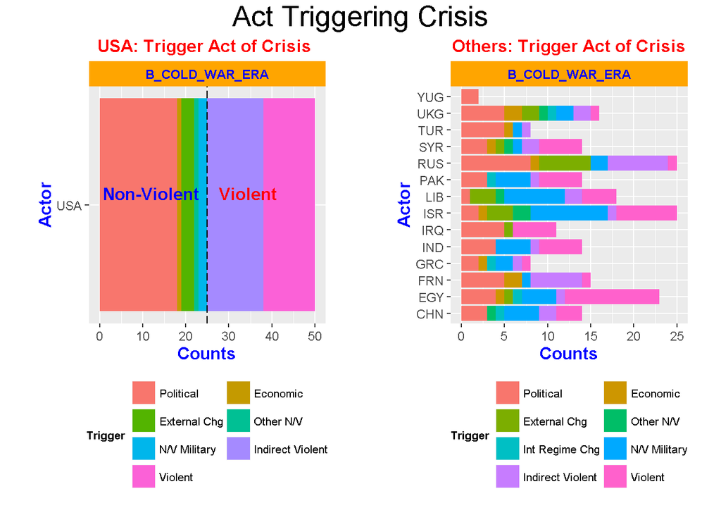

**ANALYSIS**:

- Roughly **half** of the acts triggering crisis for the USA during the cold war were non-violent in nature, the other half incorporated some form of violence. This overall trend also holds for the other actors of that period as well regardless of their crisis frequencies.

### 6.2.2 Crisis Issue

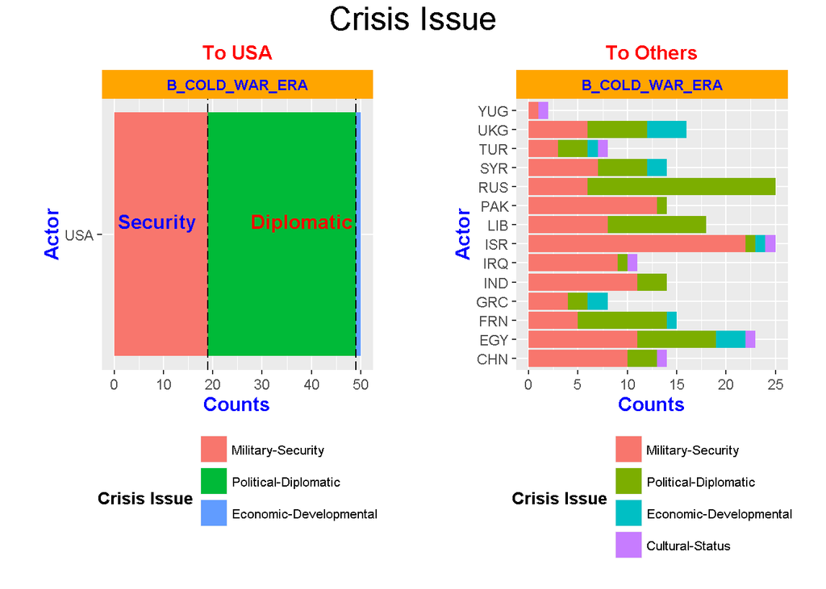

**ANALYSIS**:

- During the cold war, the dominant crisis issues for the USA were security and diplomatic in nature, with the emergence of economic as a small but viable crisis issue. Diplomatic crisis were by far the largest in frequency and is mirrored by the key USA adversary - Russia. Of the other major players in this era, those in the middle east displayed domonant crisis issues of “Military-Security” (with the notable exception of China), and lesser diplomatic issues. This is reflected in the history of the middle east during that time period. The last two notable item were (1) the emergency of “cultural” as a legitimate crisis issue in the case of Yugoslovia , Turkey, Israel, Iraq, Egypt and China, and (2) the pronounced “economic” crisis frequencies of the UK, Syria, Greece and Egypt of that period.

### 6.2.3 Actor (USA) Power Status

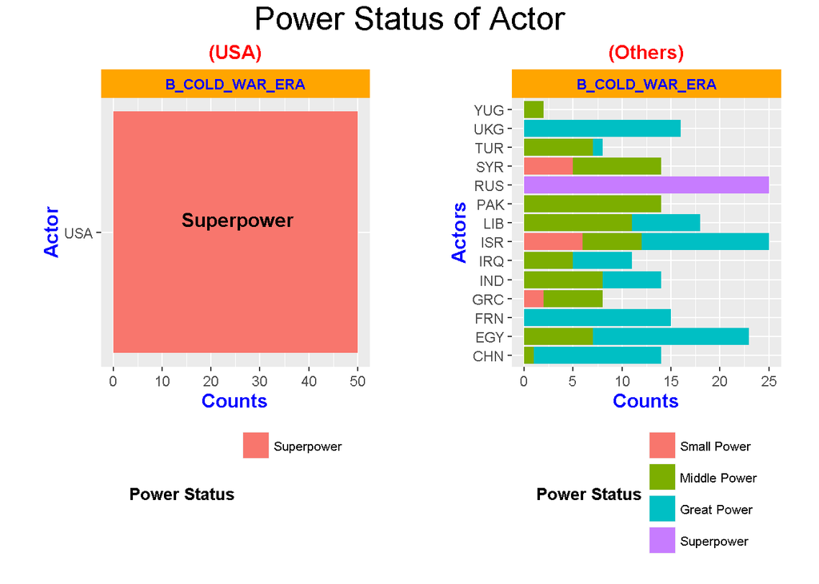

**ANALYSIS**:

### 6.2.4 Threat Power Status

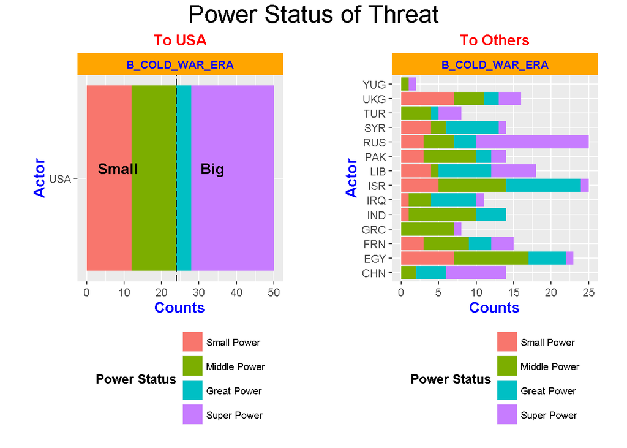

**ANALYSIS**:

### 6.2.5 Gravest Threat

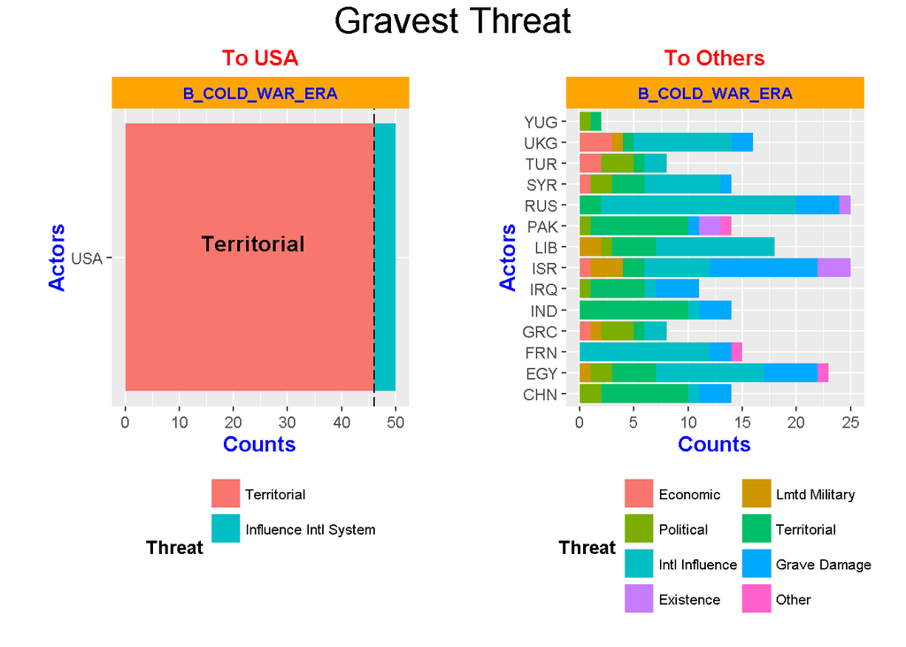

**ANALYSIS**:

It is worth pointing out that the dominant representations in the gravest threat categories of the “others” were “international influence” and “territorial”.

### 6.2.6 Major Response

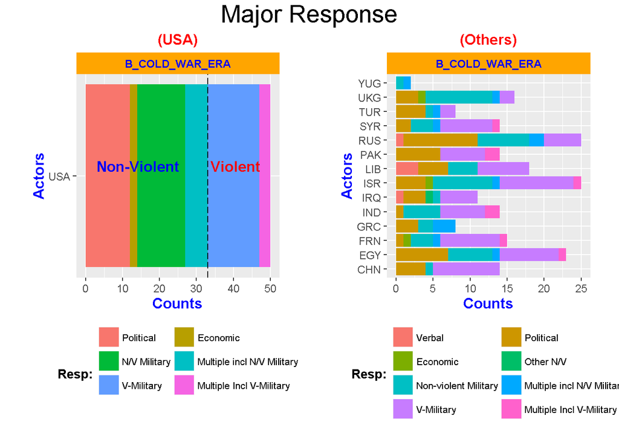

**ANALYSIS**:

- The majority of the primary responses of the USA were of non-violent nature and is roughly the same for Russia except that Russia’s “mix” of responses is quite different in that Russia did not use economic or “other” non-violent responses.
- The other major players of this era also employed non-violence about roughly half the time as well.
- The key observations for the ‘others’ category were that (1) very little economic (and other) responses were employed, (2) a great deal of political and non-violent military responses were leveraged as major responses, and (3) there were a **lot** more variations of violent responses employed across the board particularly with reguard to the middle east players, France and China.

### 6.2.7 Principle Coping Technique

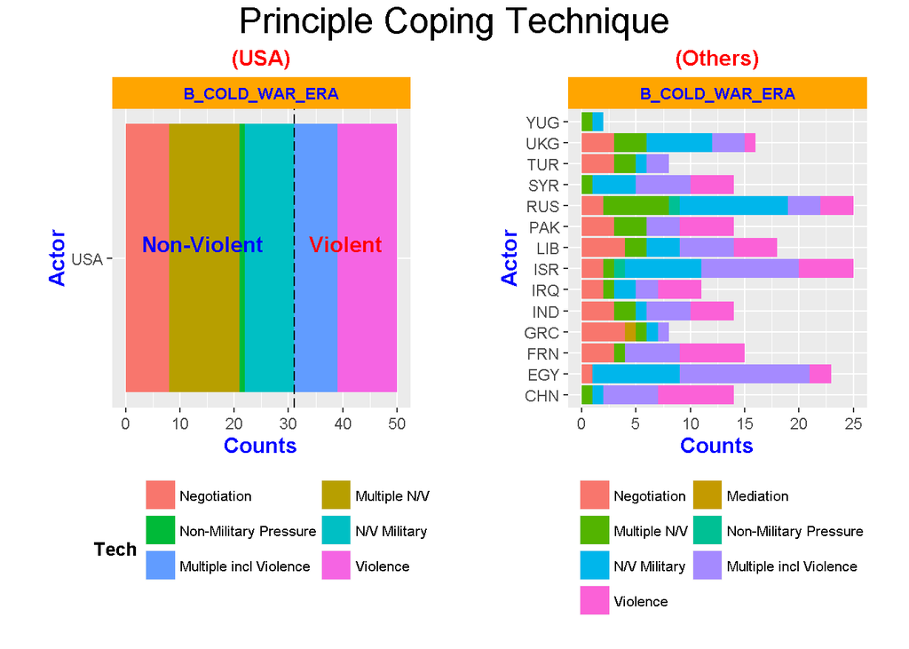

**ANALYSIS**:

- Again, the non-violent techniques are the dominant choices of both the US and Russia during the cold war era, which, given the historical context, is understandable. On the “others” side, the only coutnries to have similar mixes of violence to non-violence techniques were Yoguslovia, the UK, Turkey and Greece. The rest employed more violence than non-violence as a principle technique to their respective crises.

### 6.2.8 Violence

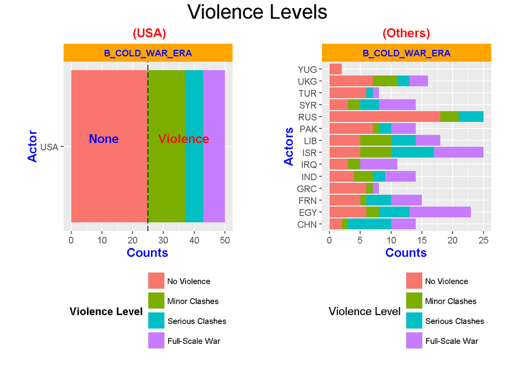

**ANALYSIS**:

### 6.2.9 Political Regime

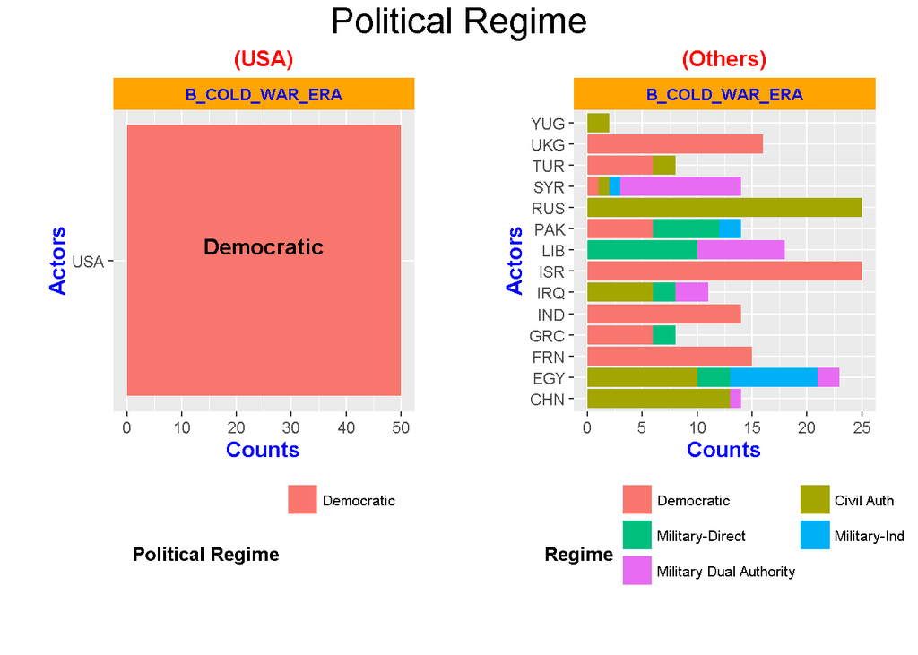

**ANALYSIS**:

- The USA being a Democracy and Russia being a Civil Authority is well established, as is the latent trend for both democracies and civil authorities to be enbroiled in a large number of interstate crises historically.
- Interesting to note is the clustering of military political regimes in the middle east: (Syria, Pakistan, Libya, Iraq, and Egypt).

### 6.2.10 Nuclear Capabilities

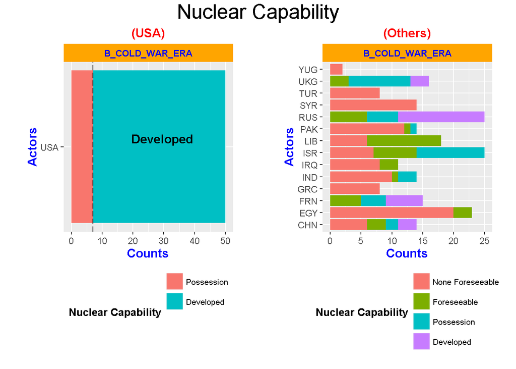

**ANALYSIS**:

- It is clear that both the USA and Russia had both “posession of” and a “developed” nuclear weapons program. The only others to do so were: China, France and the UK. Israel had posession of nuclear weapons but did not have a developed nuclear weapons program.
- It was widely believed that Libya, Israel, Iraq, and Egypt “could have develop” nuclear weapons sometime in the future, but they currently did not.
- One note is that both Pakistan and India did make entrances onto the nuclear scene independently later on and are in legitimate posession of a nuclear weapons program.

### 6.2.11 Alliance Patterns

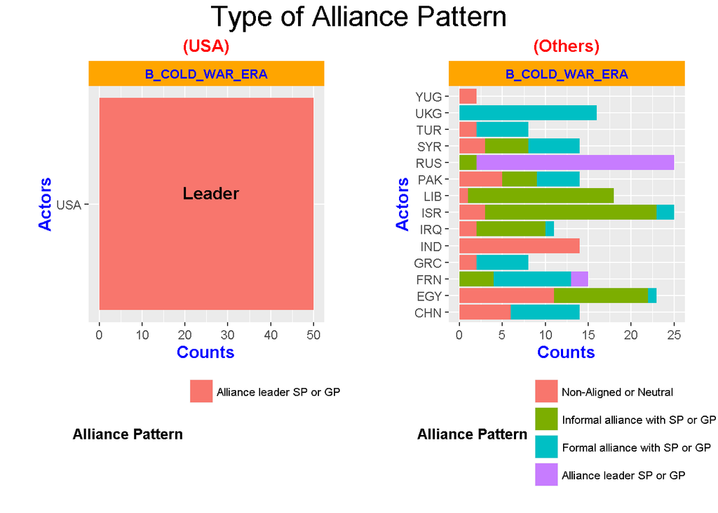

**ANALYSIS**:

### 6.2.12 Crisis Outcome

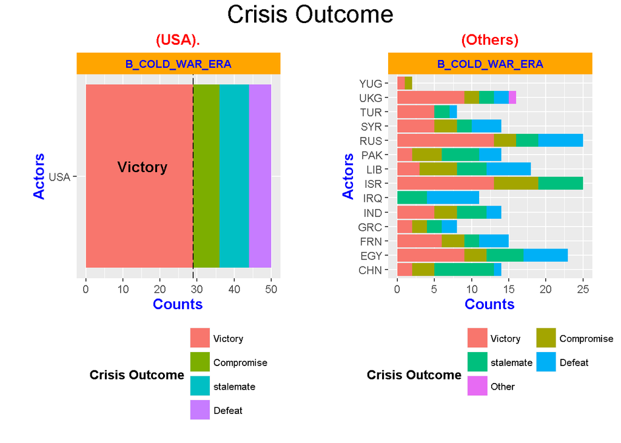

**ANALYSIS**:

- More than half of the crisis outcomes for the USA ended in a “Victory”, and the remaining half was roughly equally divided between compromise, stalmalmate, and defeat. A similar observation can be made of the Russian experience in terms of proportions of outcomes.
- There was a consistent presence of compromise and stalemate during this period across almost **all** the players, which is notable.
- Other notable exceptions are Israel, who has **never** known defeat, only victory, compromise and stalemate during this period, and Iraq which only experienced stalemate and defeat.

# 7 Final Plots

- This section is dedicated to exploring interesting multidimensional interactions of selected attributes, and other interesting phenomenon of the dataset using **Polar**, **Mosaic** and **Alluvial** plots.
- The topics explored are (1) the **“Power Difference” between the Actor and Adversary** using Polar Coordinate Plotting, (2) the relationship between **“Nuclear Capability, Actor Power Status and Crisis outcome”** using Mosaic Plotting, and (3) the **“Many Pathways to Victory (and defeat)”**, using Alluvial diagrams.
- For the convenience of the reader, I’ll provide a brief refresher on the background and interpretation of the data and/or plot types when it is useful.

### 7.0.1 Exploration of Power Difference: USA vs Adversaries

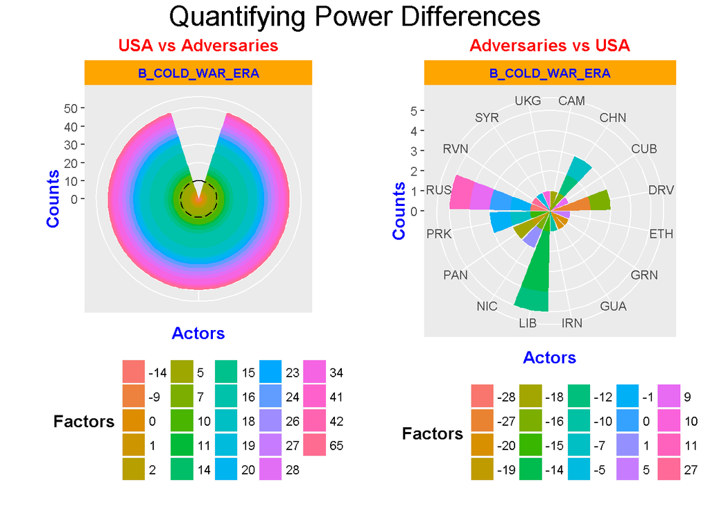

- **Refresher**: A power score was determined for each crisis actor and its principal adversary on the basis of the total of six separate scores measuring: **(1) size of population, (2) GNP, (3) territorial size, (4) alliance capability, (5) military expenditure, and (6) nuclear capability,** at the onset of the crisis. The power of a crisis actor and the power available to it from tight alliance partners was then compared to that of its principal adversary to create a **final power discrepancy score.**

**ANALYSIS**:

- **Note**: Both the direct and inverse relationships of the power differentials are examined to highlight the nuances.
- **USA vs Adversaries**: The most striking observation of the USA vs its adversaries in the cold war era is that **the USA nearly always enjoyed a huge power advantage** as evidenced by the **small dotted circle line** which is the **Power Parity** threshold line. The rest of the radius of the circle is the **positive power difference.**
- **Adversaries vs USA**: Russia obviously has achieved some measure of a positive power differential, but aside from them, only China and North Korea actually approach power “significance” with the USA. Others like Libya, Vietnam, and Panama actually have a “large negative power differential” relative to the USA, whereas the remaining group has only achieved a power differencial of “one”.

### 7.0.2 Exploration of Nuclear Capability and Power Status on Crisis Outcome

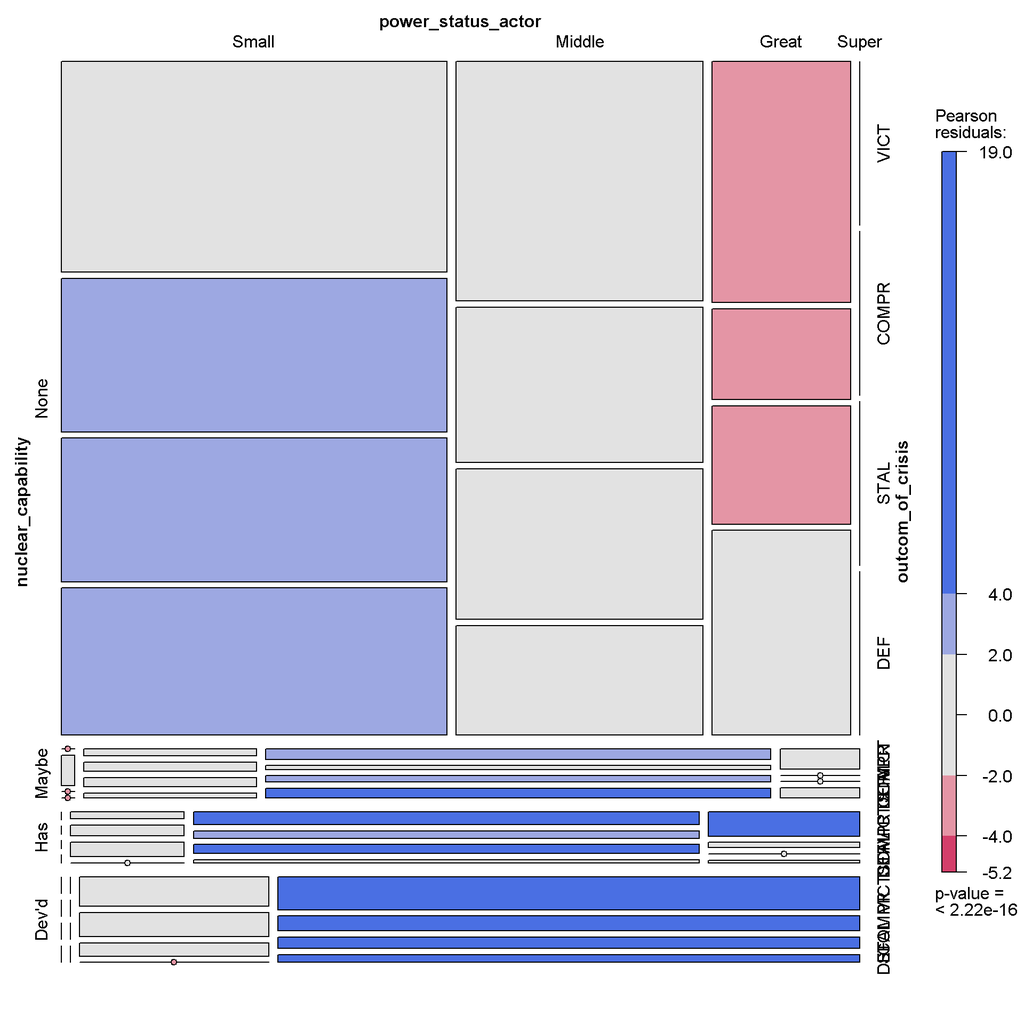

- **Refresher**: Mosaic plots visualize multivariate categorical data very well, and represent variable counts as **rectangular areas** on the plot. Each categorical variables goes to one **edge** of the square, which is subdivided by its labels into rectangles. The **size** of the rectangles is proportional to **frequency**. Mosaic plots represent the data as is, and does **not** make any attempt to “generalize to the full population”. To make **inferences** about the population, we need to provide measures of statistical significance. Inspired by the chi-square test, we can define Pearson residuals which measure the departure of each cell from “independence”. The units are in “standard deviations”“, so a residual greater than **2** or less than **-2** represents a departure significant at the **95%** level. When testing for statistical significance: **Grey** means that data are consistent with (you cannot reject the hypothesis of) variable independence, **Blue** means that a positive association exists (more observations present than expected under the null model), and **Red** means a negative association esists (fewer observations than would be expected under the null model).
- **NOTE**: This exploration comprises the **entire** ICB dataset, there is no subsetting of the data.
- **NOTE**: Unfortunately R-Markdown shrinks this graph, which makes it difficult to fully appreciate the nuances, but there is a lot of complex variable relationship information there which could still be brought to light.
- **NOTE**: On the bottom right hand side of this plot, the illegible text should reflect the 4 outcomes: (Defeat, Stalemante, Compromise, and Victory) for each of the four labels of Nuclear Capability (Developed, Has, Maybe, and None).

**ANALYSIS**:

### 7.0.3 Exploration of the “Many Pathways to Victory (and Defeat)”

- **NOTE**: These Alluvial diagrams explores how (1) Alliance Patterns, (2) Actor Power Status, and (3) Nuclear Capabilities affect the (4) Outcome (“Result”) of the crisis in question. The “pathways” to victory are marked in red to make the identification of the possibilities more clear.
1. Alliance Patterns are comprised of (None, Leader, Informal, and Formal) and are the **first** set of blocks on the left hand side of the diagrams with the subheading **Alliances**
2. Actor Power Status is comprised of (Small, Middle, Great and Super), and are the **second** set of blocks in the diagram with the subheading of **Power_Status**.
3. Nuclear Capabilities are comprised of (None, Maybe, Has, and Developed), and are the **third** set of blocks in the diagram with a subheading of **Nuclear**.
4. Outcome is comprised of (Victory, Stalemate, Compromise, Defeat and NA), and is the **forth** set of blocks in the diagram with a subheading of **Result**

### 7.0.4 Pathways to “Victory”

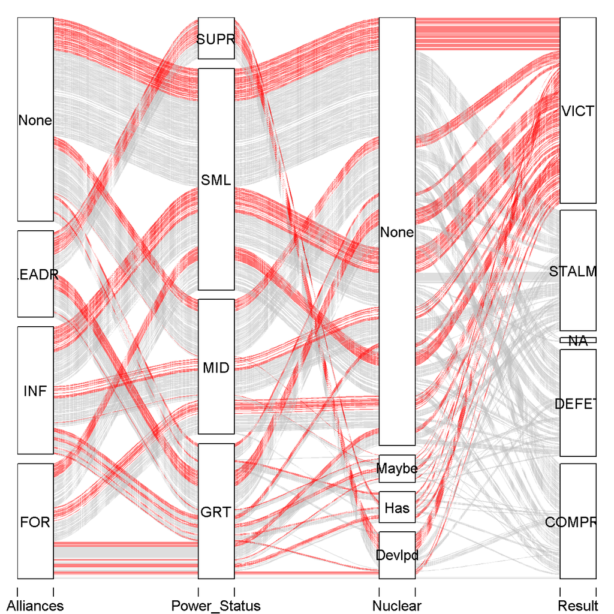

### 7.0.5 Pathways to “Defeat”

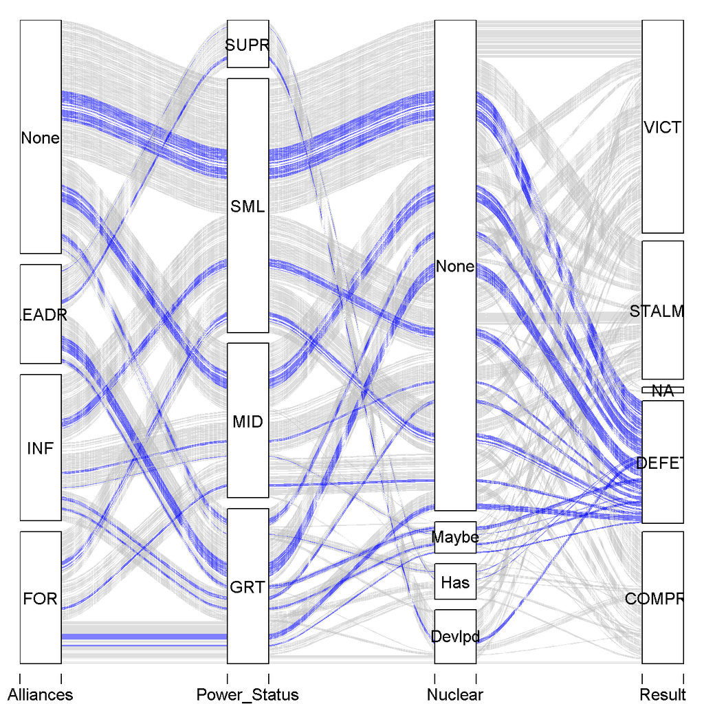

- **Refresher**: Alluvial diagrams were originally developed to visualize structural change in large complex networks, but they can be used to visualize **any** type of change in group composition between states and include statistical information to reveal significant change. Alluvial diagrams highlight important structural changes that can be further emphasized by color, and make identification of major transitions easy. We will use them to highlight the many pathways to victory (and defeat) during interstate crisis analysis.
- **NOTE**: This exploration comprises the **entire** ICB dataset, there is no subsetting of the data.

**ANALYSIS**:

- What is truly fascinating about the things this type of diagram highlights is those aspects of sovereign state crises that go in stark against “conventional” wisdom. For example: it is quite possible to be a state that with no alliances, small power, with no nuclear capabilities, and still achieve victories in conflicts. Conversely, it is also quite possible to be an alliance leader, a superpower, with a developed nuclear weapons program, and still suffer defeat.
- The other interesting notable from these sets of diagrams are the widths (frequencies) and directions of the pathways to the result as experienced through each variable in the analysis. The magnitudes of each variables influence on the outcome is can be clearly seen. For example, defeat can quite literally come from anywhere.
- **Walk through** - On the first plot, as one follows the red lines, the following inferences can be made as to the many pathways to **victory** of a crisis:
1. No alliances, Small Power, No Nuclear Capabilities.
2. No alliances, Medium Power, No Nuclear Capabilities.
3. No alliances, Great Power, No Nuclear Capabilities.
4. Informal alliances, Small Power, No Nuclear Capabilities.
5. Informal alliances, Medium Power, No Nuclear Capabilities.
6. Informal alliances, Great Power, (maybe, has, or developed) nuclear capabilities.
7. Formal alliances, Small Power, No Nuclear Capabilities.
8. Formal alliances, Medium Power, No Nuclear Capabilities.
9. Formal alliances, Great Power, (maybe, has, or developed) nuclear capabilities.
10. Alliance Leader, Great Power, (maybe, has, or developed) nuclear capabilities.
11. Alliance Leader, Super Power, (maybe, has, or developed) nuclear capabilities.

# 8 Reflections

**FUll Disclosure** - I currently work in the defense industry, and also have a passion for world history, particularly the behavior of sovereign states during conflicts, so to have the chance to analyze a dataset such as this was a real joy.

I encountered various “novelties” in this dataset immediately, the first being that nearly all of the data is either categeorical or ordinal and not the continuous data that we have seen so much of during the trainning phase of our studies. That presented some interesting challenges in terms of making the right choices for plotting vehicles since categorical variables restrict much of those choices. Second, nearly all of this data was coded numerically, and that necessitated some transformation of the data into a form which could more readily be used by the Mosaic and Alluvial plots. Third, constructing plots of this sort that captured the complex relationships and yet maintained enough elegance to make conveying the key points possible was also challenging. Forth, adhering to the spirit of “letting the data speak for itself” was difficult as it required the imposing of an overall structure that would guide the reader without getting in the way of the story. Lastly, the dataset contains 96 variables, and for the sake of brevity I only used a dozen or so very general ones in this exploration. Many of the variables not chosen contain rich information about very narrowly defined topics within the dataset which would be an entire study in their own right.

I did engage in a great deal of “developmental detours” during this project, particularly to comprehend what EDA really was across the board in data science, to understand the proper “care and handling” of categorical and ordinal variables, the intricacies of ggplot2, mosaic, alluvial diagrams, network maps, and spatial mappings in the R world, the behavioral patterns and best practices of the ggplot2 system, and a host of other adjacent fields to EDA and R which appeared useful. The price of these developmental detours was time expended to stop moving forward with the project, explore a complementary field, return to the project, incorporate that individual additions and then repeat. In truth, that made this project take up the most time of any project thus far in the program for me.

To enrich the analysis moving forward, I’d begin to make more data transformation to begin capturing more of the nuances of the data in route to uncovering the gravity of the decisions that the leaders of those sovereign states mades. I’d also begin to include more of the 96 variables (instead of just 12) in the explorations to add richness to the mix or explore more narrowly defined topics.

The success I found were in the quality of the data, which is a direct reflection of the great care and immense effort it took the ICB researchers to compile, vet, and organize that data. It made constructing a structure such that the data could readily “tell it’s own story” a reachable goal, which isn’t often the case.

I also found success in being able to procure useful R libraries such as the Alluvial library, the SQLDF, and others. They made some complex tasks much easier and extracting / visualizing interesting combinations of variables possible.

In the end I’m quite satisified with the results of this project, which for me are first and foremost the procurement of the EDA skills and implementation expierience garnered from the process, I felt like I procured a fine return on investment from this endeavor.